# teamAB2

## `Summary`

A few weeks into the quarter, you will form teams to complete this challenge. This is your final project, and each team can decide what they want to build. More than anything, this project is an opportunity to stretch your skills by diving into a dataset that you find important/interesting. As long as you meet the requirements below, the direction of your project can be quite flexible.

At the end of the quarter we will have a project fair, at which all the teams will show off what they did to the rest of the class. So do good work and build something impressive. Show off what you’ve learned, and make something you’re really proud of. Take the time to design and build something that you’d be excited to show others and include in your portfolio.

## `Requirements`

**What exactly you build is up to your group, but it must meet the following requirements:**

Create an interactive platform using R. This could be a report, slideshow, or interactive visualization (preferably compiled into a webpage for enhanced accessibility)

Choose a dataset of sufficient complexity to explore. This doesn’t mean it has to be Big Data, but it should either be of notable size (more than a few hundred observations), or complexity (more than ~5 features of each observation)

Demonstrate a nuanced understanding of the important features of the dataset. High-level insights (important descriptive information, major trends, notable outliers, etc.) should be prominent in your resource. Statistical analyses may be included if appropriate

Devise a visual representation of your data (i.e., chart, map, etc.). Ideally, this should be an interactive visualization with ability to interact with the interface (hover, click, drag, etc.), or change the data being displayed (i.e., the chart responds to a set of controls, such as which data is being displayed)

Tailor your resource to a specific target audience. The way you frame your solution for a scientific versus general audience is quite different

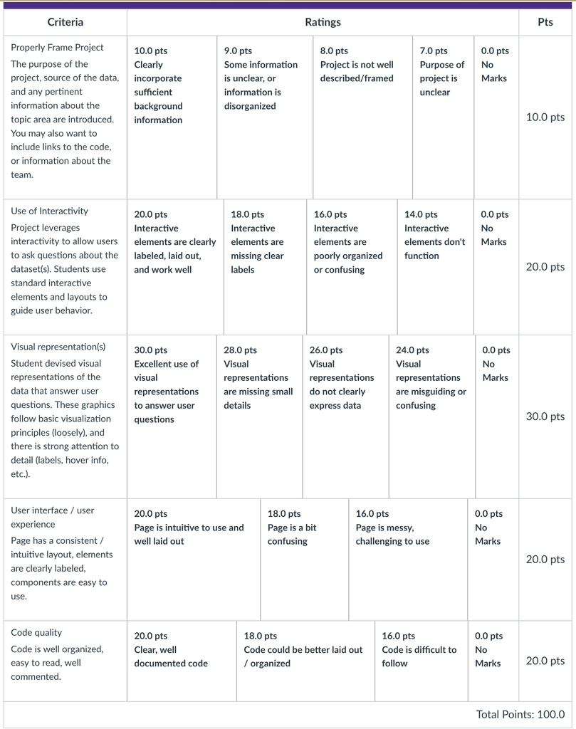

Rubric